# STAT 413/613 HW 2: stringr and lubridate

Jaehee Lee

2021-02-17

# Instructions

Rename the starter file under the analysis directory as `hw_02_yourname.Rmd` and use it for your solutions.  
1. Modify the “author” field in the YAML header.  
2. Stage and Commit R Markdown and HTML files (no PDF files).  
3. **Push both .Rmd and HTML files to GitHub**.  
- Make sure you have knitted to HTML prior to staging, committing, and pushing your final submission.  
4. **Commit each time you answer a part of question, e.g. 1.1**  
5. **Push to GitHub after each major question**, e.g., Scrabble and Civil War Battles  
- **Committing and Pushing are graded elements for this homework.**  
6. When complete, submit a response in Canvas

- Only include necessary code to answer the questions.
- Most of the functions you use should be from the tidyverse. Too much base R will result in point deductions.
- Use Pull requests and or email to ask me any questions. If you email, please ensure your most recent code is pushed to GitHub.
- Learning objectives:
  - Manipulate dates and times with lubridate.

# 1 Scrabble Words

For this exercise, we are using the [Collins Scrabble Words](https://en.wikipedia.org/wiki/Collins_Scrabble_Words), which is most commonly used outside of the United States. The dictionary most often used in the United States is the [Tournament Word List](https://en.wikipedia.org/wiki/Official_Tournament_and_Club_Word_List).

**WARNING**: Do not try `str_view()` or `str_view_all()` on these data.It will stall your computer. load packages

```r
library(tidyverse)
library(stringr)
library(readr)
library(lubridate)
```

1. Use a readr function to load the 2015 list of Collins Scrabble Words into R from your data folder or from https://data-science-master.github.io/lectures/data/words.txt
   - (note: “NA” is an official Scrabble word).

```r
read_delim('https://data-science-master.github.io/lectures/data/words.txt', delim = "|") -> collins_scrabble
```

2. What are the six longest words that have the most “X”’s in them?

```r
collins_scrabble %>%
  mutate(length_of_word = str_length(word)) %>%  #make new column for length_of_word
  mutate(count_X = str_count(word,"X")) %>% #make new column for counting "X"
  arrange(desc(count_X)) -> collins_scrabble_1

collins_scrabble_1 %>%
  select(count_X) %>%
  head(1) -> most_X  #This will tell me the most "X"'s count which is 2

collins_scrabble_1 %>%
  filter(count_X == most_X$count_X[1]) %>%
  arrange(desc(length_of_word)) %>%
  head() %>%  # show 6 longest words
  select(word)
```

```
## # A tibble: 6 x 1
##   word
##   <chr>
## 1 COEXECUTRIXES
## 2 EXTRATEXTUAL
## 3 COEXECUTRIX
## 4 EXECUTRIXES
## 5 SAXITOXINS
## 6 XANTHOXYLS
```

3. How many words have an identical first and second half of the word? If a word has an odd number of letters, exclude the middle character.
- MURMUR counts because MUR is both the first and second half.
- JIGAJIG counts because the middle A is excluded so JIG is both the first and second half.
- Save the results to a variable.

```r
collins_scrabble_1 %>%
  mutate(is_even = if_else(str_length(word) %% 2 == 0,  "yes", "no")) %>%
  mutate(first_half = if_else(is_even == "yes",
                              str_sub(word, 1, length_of_word/2), str_sub(word, 1, floor(length_of_word/2)))) %>%
  mutate(second_half = if_else(is_even == "no",
                               str_sub(word, (length_of_word/2)+1, length_of_word), str_sub(word, ceiling(length_of_word/2 +1), length_of_word))) %>%
  filter(first_half == second_half) -> collins_scrabble_2

collins_scrabble_2 %>%
  tally() -> number_identical_first_and_second_half
```

4. Use the results from 3 to find the longest word with an identical first and second half of the word?

```r
collins_scrabble_2 %>%
  arrange(desc(length_of_word)) %>%
  head(1) %>%
  select(word)
```

```
## # A tibble: 1 x 1
##   word
##   <chr>
## 1 CHIQUICHIQUI
```

# 2 Civil War Battles

The data in “civil_war_theater.csv” contains a information on American Civil War battles, taken from [Wikipedia](https://en.wikipedia.org/wiki/List_of_American_Civil_War_battles).

Variables include:

- `Battle`: The name of the battle.
- `Date`: The date(s) of the battle in different formats depending upon the length of the battle.
  - If it took place on one day, the format is “month day, year”.
  - If it took place over multiple days, the format is “month day_start-day_end, year”.
  - If it took place over multiple days and months, the format is “month_start day_start - month_end day_end, year”.
  - If it took place over multiple days,months, and years, the format is “month_start day_start, year_start - month_end day_end, year_end”.
- `State`: The state where the battle took place. Annotations (e.g. describing that the state was a territory at the time) are in parentheses.
- `CWSAC`: A rating of the military significance of the battle by the Civil War Sites Advisory Commission. `A` = Decisive, `B` = Major, `C` = Formative, `D` = Limited.
- `Outcome`: Usually `"Confederate victory"`, `"Union victory"`, or `"Inconclusive"`, followed by notes.
- `Theater`: An attempt to to identify which theater of war is most associated with the battle
1. Use a readr function and relative paths to load the data into R.

```r
civil_war_data <- read_csv("../data/civil_war_theater.csv")
str(civil_war_data)
```

```
## spec_tbl_df [384 × 6] (S3: spec_tbl_df/tbl_df/tbl/data.frame)
##  $ Battle : chr [1:384] "Battle of Fort Stevens" "Battle of Hancock" "Battle of South Mountainor Boonsboro" "Battle of Antietam or Sharpsburg" ...
##  $ Date   : chr [1:384] "July 11-12, 1864" "January 5-6, 1862" "September 14, 1862" "September 17, 1862" ...
##  $ State  : chr [1:384] "District of Columbia" "Maryland" "Maryland" "Maryland" ...
##  $ CWSAC  : chr [1:384] "B" "D" "B" "A" ...
##  $ Theater: chr [1:384] "Eastern" "Eastern" "Eastern" "Eastern" ...
##  $ Outcome: chr [1:384] "Union victory: Failed Confederate attempt to capture Washington, D.C., President Lincoln, observing the battle,"| __truncated__ "Inconclusive: Unsuccessful Confederate attack on Maryland town." "Union victory: McClellan defeats Lee." "Tactically inconclusive; strategic Un…
##  - attr(*, "spec")=
##   .. cols(
##   ..   Battle = col_character(),
##   ..   Date = col_character(),
##   ..   State = col_character(),
##   ..   CWSAC = col_character(),
##   ..   Theater = col_character(),
##   ..   Outcome = col_character()
##   .. )
```

The next several questions will help you take the dates from all the different formats and create a consistent set of start date and end date variables in the data frame. We will start by calculating how many years, and months are in each battle.

2. Add a variable to the data frame with the number of years for each battle.
- Create a character variable as follows. This can be used as a pattern in a regular expression.
- Use `year_regex` to now count the number of years in each battle, add this to the data frame, and save the data frame.

```r
year_regex <- stringr::str_c(1861:1865, collapse = "|")
year_regex
```

```
## [1] "1861|1862|1863|1864|1865"
```

```r
civil_war_data %>%
  mutate(year = str_extract_all(Date, year_regex)) %>%
  mutate(year_count = str_count(Date, year_regex))->civil_war_data
```

3. Add a variable to the data frame with the number of months for each battle.
- Consider R’s built-in vector of month names: `month.name`.
- Use `month.name` to count the number of month names in the `Date` variable in each battle.
- Add this to the data frame. (You might need to do something similar to what we did in part 2).

```r
month_regex <- stringr::str_c(month.name, collapse = "|")
month_regex
```

```
## [1] "January|February|March|April|May|June|July|August|September|October|November|December"
```

```r
civil_war_data %>%
  mutate(month_names = str_extract_all(Date, month_regex)) %>%
  mutate(month_count = str_count(Date, month_regex)) -> civil_war_data
```

4. Add a variable to the data frame that is `TRUE` if `Date` spans multiple days and is `FALSE` otherwise. Spanning multiple months and/or years also counts as `TRUE`.

```r
civil_war_data %>%
  mutate(hyphen = str_detect(Date, "-")) %>%
  mutate(multiple_days = if_else(hyphen == "TRUE",  "TRUE", "FALSE")) -> civil_war_data
```

5. Make four new data frames by filtering the data based on the length of the battles:
   - a data frame with the data for only those battles spanning just one day,

```r
civil_war_data %>%
  filter(multiple_days == "FALSE") -> one_day
```

- a data frame with the data for only those battles spanning multiple days in just one month,

```r
civil_war_data %>%
  filter(multiple_days == "TRUE") %>%
  filter(year_count == 1) %>%
  filter(month_count == 1) %>%
  filter(hyphen == "TRUE") -> multiple_days_1month
```

- a data frame with the data for only those battles spanning multiple months but not multiple years, and,

```r
civil_war_data %>%
  filter(multiple_days == "TRUE") %>%
  filter(year_count == 1) %>%
  filter(month_count == 2) -> months_not_years
```

- a data frame with the data for only those battles spanning multiple years.

```r
civil_war_data %>%
  filter(multiple_days == "TRUE") %>%
  filter(year_count == 2) -> multiple_years
```

6. For each of the four new data frames,
- Add two new variables:
  - `Start` should contain the start-date of each battle.
  - `End` should contain the end-date of each battle.
  - Hint: look at help for `separate()`
  - Make sure these are `Date` class objects.
- Remove the `Date` variable from each data frame.
- Save the data frames with the new variables

```r
# 1
one_day %>%
  mutate(Start = Date) %>%
  mutate(End = Date) %>%
  select(-Date)-> one_day_updated

one_day_updated %>%
  mutate(Start = mdy(Start)) %>%
  mutate(End = mdy(End)) -> one_day_updated

#2
separate(data = multiple_days_1month, col = Date, sep = "-", into = c("Start", "End")) -> multiple_days_1month_new
multiple_days_1month_new %>%
  unite(Start, c("Start", "year")) %>%
  unite(End, c("End", "month_names")) -> multiple_days_1month_new
multiple_days_1month_new %>%
  mutate(Start = mdy(Start)) %>%
  mutate(End = dym(End)) ->multiple_days_1month_new

# 3
separate(data = months_not_years, col = Date, sep = "-", into = c("Start", "End")) -> months_not_years_new
months_not_years_new %>%
  unite(Start, c("Start", "year")) -> months_not_years_new

months_not_years_new %>%
  mutate(Start = mdy(Start)) %>%
  mutate(End = mdy(End)) -> months_not_years_new
# 4
separate(data = multiple_years, col = Date, sep = "-", into=c("Start", "End")) -> multiple_years_updated

multiple_years_updated %>%
  mutate(Start = mdy(Start)) %>%
  mutate(End = mdy(End)) -> multiple_years_updated
```

7. Create a new data frame with all the battles and the Start and End dates by binding the rows of the four data frames as updated in part 6

```r
bind_rows(one_day_updated, multiple_days_1month_new,months_not_years_new, multiple_years_updated) -> civil_war
```

8. Calculate the number of days each battle spanned.
- What’s the longest battle of the war?
- How long did it last?

```r
# 1 way to solve Question 8
civil_war$days_spanned <- civil_war$End - civil_war$Start
civil_war %>%
  arrange(desc(days_spanned)) %>%
  head(1) %>%
  select(Battle, days_spanned)-> the_longest_battle_0
the_longest_battle_0
```

```
## # A tibble: 1 x 2
##   Battle               days_spanned
##   <chr>                <drtn>
## 1 Siege of Port Hudson 49 days
```

```r
# 2 way to solve Question 8
civil_war %>%
  mutate(days = difftime(civil_war$Start, civil_war$End, units = "days")) %>%
  arrange(-desc(days)) -> civil_war_with_days
civil_war_with_days$days <- abs(civil_war_with_days$days)

civil_war_with_days %>%
 head(1) %>%
 select(Battle, days) -> the_longest_battle
the_longest_battle
```

```
## # A tibble: 1 x 2
##   Battle               days
##   <chr>                <drtn>
## 1 Siege of Port Hudson 49 days
```

9. Is there an association between the CWSAC significance of a battle and its duration?  
   -Extra Credit: Test for a linear relationship using lm() and interpret the results in one sentence based on the p -value and adjusted R-squared.

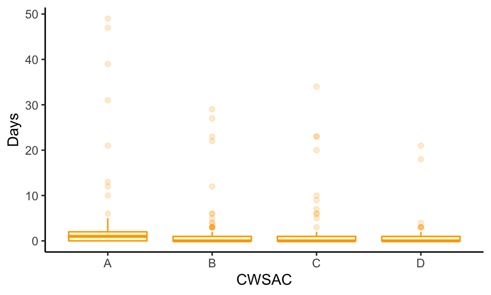

```r
# - Create an appropriate plot.
library(ggplot2)
library(ggthemes)
ggplot(data = civil_war, aes(y = days_spanned , x =factor(CWSAC)))+
  geom_boxplot(color="orange", fill="yellow", alpha=0.2)+
  xlab("CWSAC")+
  ylab("Days")+
  theme_classic()
```

```r
# - Interpret the plot in one sentence to answer the question.
# When 'A rating of the military significance of the battle by the Civil War Sites Advisory Commission' is `A` = #Decisive,the days of the battle spanned have the highest median compared to other `B` = Major, `C` = Formative, `D` = #Limited

# -Extra Credit: Test for a linear relationship using lm() and interpret the results in one sentence based on the p-value and adjusted R-squared.

# Convert to numeric value
civil_war$day_numeric = as.numeric(civil_war$days_spanned)/(24*60*60)

fit <- lm(day_numeric ~ factor(CWSAC), data = civil_war)

summary(fit)
```

```
##
## Call:
## lm(formula = day_numeric ~ factor(CWSAC), data = civil_war)
##
## Residuals:
##        Min         1Q     Median         3Q        Max
## -6.687e-05 -2.092e-05 -9.350e-06 -7.870e-06  5.003e-04
##
## Coefficients:
##                  Estimate Std. Error t value Pr(>|t|)
## (Intercept)     6.687e-05  9.983e-06   6.699 7.60e-11 ***
## factor(CWSAC)B -4.595e-05  1.195e-05  -3.845 0.000141 ***
## factor(CWSAC)C -5.083e-05  1.162e-05  -4.375 1.57e-05 ***
## factor(CWSAC)D -5.776e-05  1.188e-05  -4.861 1.71e-06 ***
## ---
## Signif. codes:  0 '***' 0.001 '**' 0.01 '*' 0.05 '.' 0.1 ' ' 1
##
## Residual standard error: 6.697e-05 on 380 degrees of freedom
## Multiple R-squared:  0.0622, Adjusted R-squared:  0.0548
## F-statistic: 8.401 on 3 and 380 DF,  p-value: 2.026e-05
```

```r
# Interpret the results: p-value is 2.026e-05, so p-value is very close to 0 indicating that the results are significant, and Adjusted R-squared is  0.0548, indicates that this fit is weak linear fit for the model, so maybe I have to change or add more variables.
```

```r
civil_war %>%
  mutate(State = replace(State, State == "West Virginia (Virginia at the time)", "West Virginia")) %>%
  mutate(State = replace(State, State == "Oklahoma (Indian Territory at the time)", "Oklahoma")) %>%
  mutate(State = replace(State, State == "Colorado (Colorado Territory at the time)", "Colorado")) %>%
  mutate(State = replace(State, State == "North Dakota", "North Dakota (Dakota Territory  at the time)")) -> civil_war
civil_war %>%
  group_by(State, Theater) %>%
  summarise(Freq=n()) %>%
  arrange(desc(Freq))  %>%
  tail(9) %>%
  ungroup()  -> filtered_out
filtered_out
```

```
## # A tibble: 9 x 3
##   State                                         Theater            Freq
##   <chr>                                         <chr>             <int>
## 1 New Mexico (New Mexico Territory at the time) Western               2
## 2 North Dakota (Dakota Territory at the time)   Western               2
## 3 Ohio                                          Trans-Mississippi     2
## 4 Pennsylvania                                  Eastern               2
## 5 Texas                                         Lower Seaboard        2
## 6 Colorado                                      Western               1
## 7 District of Columbia                          Eastern               1
## 8 Idaho (Washington Territory at the time)      Western               1
## 9 Indiana                                       Trans-Mississippi     1
```

```r
civil_war %>%
  filter(State != "Pennsylvania" ) %>%
  filter(State != "Colorado"  ) %>%
  filter(State != "New Mexico (New Mexico Territory at the time)" ) %>%
  filter(State != "North Dakota (Dakota Territory at the time)" ) %>%
  filter(State != "Ohio" ,)  %>%
  filter(State != "District of Columbia"  ) %>%
  filter(Battle != "Bear River Massacre") %>%
  filter(Battle != "Battle of Valverde") %>%
  filter(Battle != "Battle of Glorieta Pass") %>%
  filter(State != "Indiana" ) -> civil_war_1
```

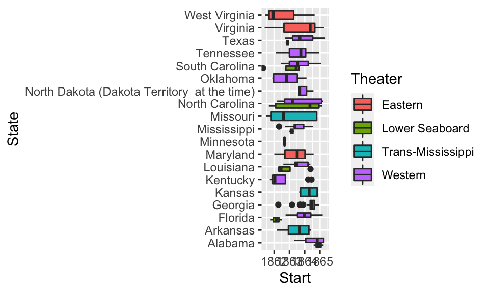

```r
 ggplot(civil_war_1, aes(x=State, y=Start, fill = Theater))+
  geom_boxplot()+
  coord_flip()
```